# ML practice 3: Cross-validation, bias-variance tradeoff

Сегодня говорим о нескольких важных понятиях в машинном обучении, но сначала – повторение

**Ваша очередь:**

- Зачем нужно разделение на тестовую и обучающую выборки?
- Как вы думаете, зачем иногда делят на три части train-validation-test?

### Напоминание

**Переобучение** – слишком сложная модель (включение лишних переменных, слишком сложная зависимость) => подогнали модель к конкретным данным, может не работать на других данных

**Недообучение** – слишком простая модель (невключение важных переменных, слишком простая зависимость) => модель не отражает особенности данных

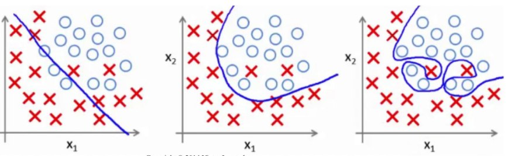

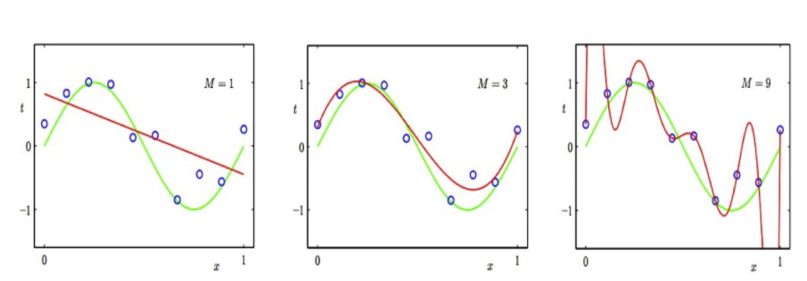

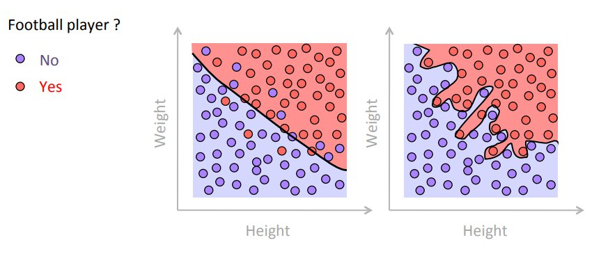

## Bias-Variance Tradeoff

В целом, ошибку предсказания модели можно разложить на три составляющие

Error = Irreducible Error + Bias + Variance

- Irreducible Error = ошибка, обусловленная данными (в них есть разброс, отклонения, выбросы)
- Bias = отклонение модели от данных
- Variance = вариативность значений предсказываемой переменной (разнообразие предсказаний относительно среднего)

И еще про переобучение и ошибку

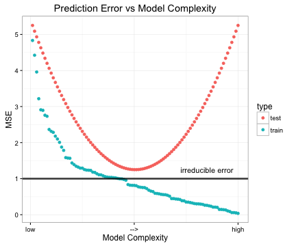

### Данные: классификация

Работаем с данными про типы стекла

```r
library(mlbench)
data(Glass)
#?Glass
table(Glass$Type)
```

```
##
##  1  2  3  5  6  7
## 70 76 17 13  9 29
```

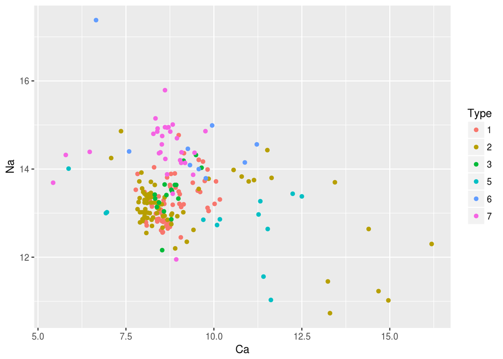

```r
library(ggplot2)
ggplot(data = Glass) + geom_point(aes(x = Ca, y = Na, col = Type))
```

Разобьем на тестовую и обучающую. Сегодня сделаем это с помощью функций пакета `caret`

```r
library(caret)
set.seed(3456)
trainIndex <- createDataPartition(Glass$Type, p = .8,
                                  list = FALSE,
                                  times = 1)
head(trainIndex)
```

```
##      Resample1
## [1,]         1
## [2,]         2
## [3,]         3
## [4,]         4
## [5,]         5
## [6,]         6
```

```r
GlassTrain <- Glass[ trainIndex,]
GlassTest  <- Glass[-trainIndex,]
```

Строим дерево решений

```r
library(partykit)
```

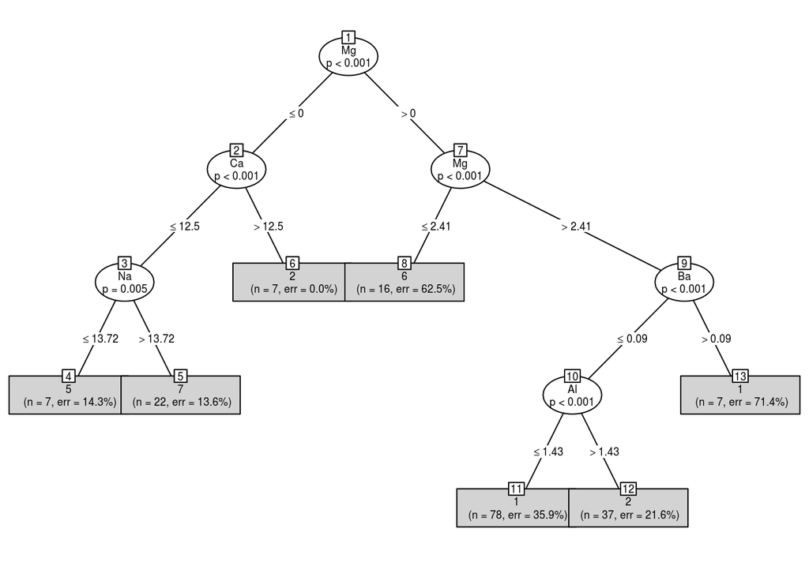

```r
modelTree<-ctree(Type~., data=GlassTrain)
plot(modelTree, type = "simple", gp = gpar(cex=0.55))
```

Предсказание на обучающей выборке

```r
Glass.predictionsTrain <- predict(modelTree, GlassTrain)
head(Glass.predictionsTrain)
```

```
## 1 2 3 4 5 6
## 1 1 2 1 1 2
## Levels: 1 2 3 5 6 7
```

```r
cmTr = confusionMatrix(Glass.predictionsTrain, GlassTrain$Type)
cmTr
```

```
## Confusion Matrix and Statistics
##
##           Reference
## Prediction  1  2  3  5  6  7
##          1 52 20 10  1  0  2
##          2  4 36  4  0  0  0
##          3  0  0  0  0  0  0
##          5  0  1  0  6  0  0
##          6  0  3  0  4  6  3
##          7  0  1  0  0  2 19
##
## Overall Statistics
##
##                Accuracy : 0.6839
##                  95% CI : (0.6092, 0.7522)
##     No Information Rate : 0.3506
##     P-Value [Acc > NIR] : < 2.2e-16
##
##                   Kappa : 0.5669
##  Mcnemar's Test P-Value : NA
##
## Statistics by Class:
##
##                      Class: 1 Class: 2 Class: 3 Class: 5 Class: 6 Class: 7
## Sensitivity            0.9286   0.5902  0.00000  0.54545  0.75000   0.7917
## Specificity            0.7203   0.9292  1.00000  0.99387  0.93976   0.9800
## Pos Pred Value         0.6118   0.8182      NaN  0.85714  0.37500   0.8636
## Neg Pred Value         0.9551   0.8077  0.91954  0.97006  0.98734   0.9671
## Prevalence             0.3218   0.3506  0.08046  0.06322  0.04598   0.1379
## Detection Rate         0.2989   0.2069  0.00000  0.03448  0.03448   0.1092
## Detection Prevalence   0.4885   0.2529  0.00000  0.04023  0.09195   0.1264
## Balanced Accuracy      0.8245   0.7597  0.50000  0.76966  0.84488   0.8858
```

Предсказание на тестовой выборке

```r
Glass.predictionsTest <- predict(modelTree, GlassTest)
head(Glass.predictionsTest)
```

```
## 10 11 12 17 32 38
##  1  2  1  1  1  1
## Levels: 1 2 3 5 6 7
```

```r
cmTest = confusionMatrix(Glass.predictionsTest, GlassTest$Type)
cmTest
```

```
## Confusion Matrix and Statistics
##
##           Reference
## Prediction  1  2  3  5  6  7
##          1 13  7  3  0  0  1
##          2  1  7  0  0  0  0
##          3  0  0  0  0  0  0
##          5  0  0  0  1  0  1
##          6  0  1  0  1  0  0
##          7  0  0  0  0  1  3
##
## Overall Statistics
##
##                Accuracy : 0.6
##                  95% CI : (0.4333, 0.7514)
##     No Information Rate : 0.375
##     P-Value [Acc > NIR] : 0.003206
##
##                   Kappa : 0.4275
##  Mcnemar's Test P-Value : NA
##
## Statistics by Class:
##
##                      Class: 1 Class: 2 Class: 3 Class: 5 Class: 6 Class: 7
## Sensitivity            0.9286   0.4667    0.000   0.5000   0.0000   0.6000
## Specificity            0.5769   0.9600    1.000   0.9737   0.9487   0.9714
## Pos Pred Value         0.5417   0.8750      NaN   0.5000   0.0000   0.7500
## Neg Pred Value         0.9375   0.7500    0.925   0.9737   0.9737   0.9444
## Prevalence             0.3500   0.3750    0.075   0.0500   0.0250   0.1250
## Detection Rate         0.3250   0.1750    0.000   0.0250   0.0000   0.0750
## Detection Prevalence   0.6000   0.2000    0.000   0.0500   0.0500   0.1000
## Balanced Accuracy      0.7527   0.7133    0.500   0.7368   0.4744   0.7857
```

- А что будет, если сделать другое разбиение на тестовую и обучающую выборки?

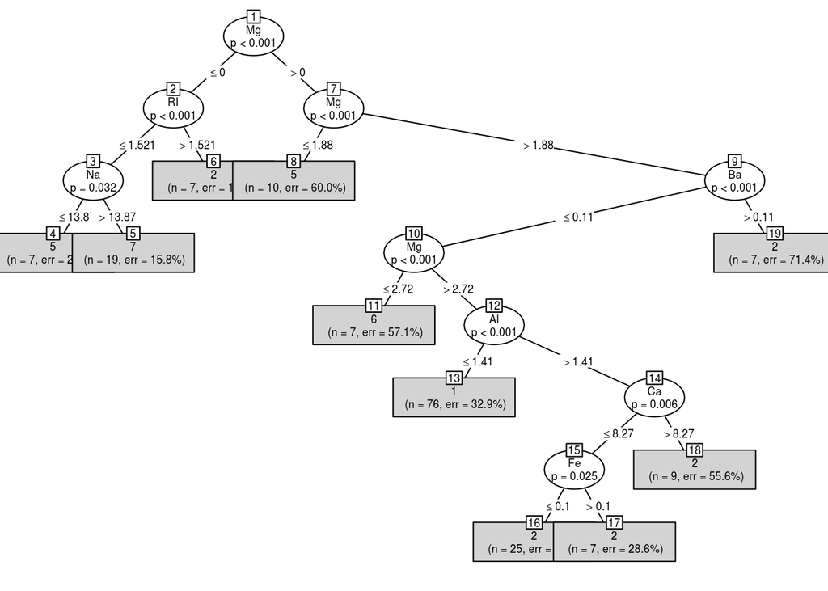

```r
set.seed(1)
trainIndex2 <- createDataPartition(Glass$Type, p = .8,
                                  list = FALSE,
                                  times = 1)
GlassTrain2 <- Glass[ trainIndex2,]
GlassTest2  <- Glass[-trainIndex2,]
modelTree2<-ctree(Type~., data=GlassTrain2)

plot(modelTree2, type = "simple", gp = gpar(cex=0.55))
```

```r
Glass.predictionsTrain2 <- predict(modelTree2, GlassTrain2)
cmTr2 = confusionMatrix(Glass.predictionsTrain2, GlassTrain2$Type)
cmTr2
```

```
## Confusion Matrix and Statistics
##
##           Reference
## Prediction  1  2  3  5  6  7
##          1 51 15  9  0  0  1
##          2  4 42  5  2  0  2
##          3  0  0  0  0  0  0
##          5  0  2  0  9  2  4
##          6  1  2  0  0  3  1
##          7  0  0  0  0  3 16
##
## Overall Statistics
##
##                Accuracy : 0.6954
##                  95% CI : (0.6212, 0.7628)
##     No Information Rate : 0.3506
##     P-Value [Acc > NIR] : < 2.2e-16
##
##                   Kappa : 0.5802
##  Mcnemar's Test P-Value : NA
##
## Statistics by Class:
##
##                      Class: 1 Class: 2 Class: 3 Class: 5 Class: 6 Class: 7
## Sensitivity            0.9107   0.6885  0.00000  0.81818  0.37500  0.66667
## Specificity            0.7881   0.8850  1.00000  0.95092  0.97590  0.98000
## Pos Pred Value         0.6711   0.7636      NaN  0.52941  0.42857  0.84211
## Neg Pred Value         0.9490   0.8403  0.91954  0.98726  0.97006  0.94839
## Prevalence             0.3218   0.3506  0.08046  0.06322  0.04598  0.13793
## Detection Rate         0.2931   0.2414  0.00000  0.05172  0.01724  0.09195
## Detection Prevalence   0.4368   0.3161  0.00000  0.09770  0.04023  0.10920
## Balanced Accuracy      0.8494   0.7867  0.50000  0.88455  0.67545  0.82333
```

```r
Glass.predictionsTest2 <- predict(modelTree2, GlassTest2)
cmTest2 = confusionMatrix(Glass.predictionsTest2, GlassTest2$Type)
cmTest2
```

```
## Confusion Matrix and Statistics
##
##           Reference
## Prediction  1  2  3  5  6  7
##          1 11  8  3  0  0  0
##          2  3  6  0  0  0  0
##          3  0  0  0  0  0  0
##          5  0  1  0  2  0  0
##          6  0  0  0  0  1  0
##          7  0  0  0  0  0  5
##
## Overall Statistics
##
##                Accuracy : 0.625
##                  95% CI : (0.458, 0.7727)
##     No Information Rate : 0.375
##     P-Value [Acc > NIR] : 0.001169
##
##                   Kappa : 0.4667
##  Mcnemar's Test P-Value : NA
##
## Statistics by Class:
##
##                      Class: 1 Class: 2 Class: 3 Class: 5 Class: 6 Class: 7
## Sensitivity            0.7857   0.4000    0.000   1.0000    1.000    1.000
## Specificity            0.5769   0.8800    1.000   0.9737    1.000    1.000
## Pos Pred Value         0.5000   0.6667      NaN   0.6667    1.000    1.000
## Neg Pred Value         0.8333   0.7097    0.925   1.0000    1.000    1.000
## Prevalence             0.3500   0.3750    0.075   0.0500    0.025    0.125
## Detection Rate         0.2750   0.1500    0.000   0.0500    0.025    0.125
## Detection Prevalence   0.5500   0.2250    0.000   0.0750    0.025    0.125
## Balanced Accuracy      0.6813   0.6400    0.500   0.9868    1.000    1.000
```

Сравним точности

```r
cmTest$overall["Accuracy"]
```

```
## Accuracy
##      0.6
```

```r
cmTest2$overall["Accuracy"]
```

```
## Accuracy
##    0.625
```

Посмотрим на одном и том же тестовом датасете

```r
Glass.predictionsTest3 <- predict(modelTree2, GlassTest)
cmTest3 = confusionMatrix(Glass.predictionsTest3, GlassTest$Type)
cmTest$overall["Accuracy"]
```

```
## Accuracy
##      0.6
```

```r
cmTest3$overall["Accuracy"]
```

```
## Accuracy
##     0.65
```

- Какое значение правильное? Как выбрать?

### Cross-validation

- Что делать, если при случайном выборе нам попалась очень специфичная обучающая выборка?

Кросс-валидация = повторение процесса с разделением на тестовую и обучающую несколько раз и подсчет среднего значения

#### k-fold Cross Validation

- разделяем на k частей
- используем k-1 часть как обучающую, последнюю – как тестовую
- повторяем k раз
- считаем среднее

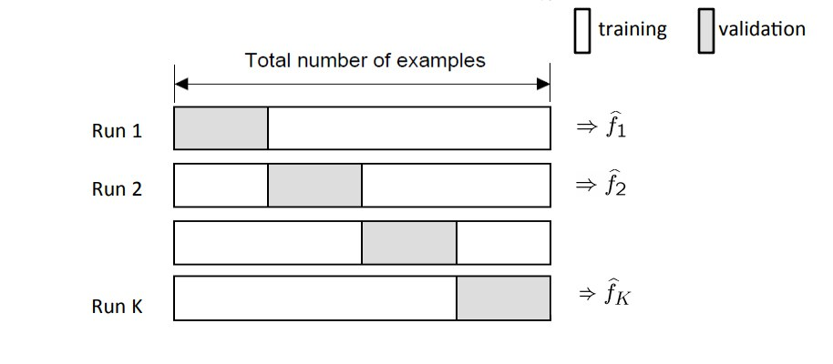

```r
train_control <- trainControl(method="cv", number=10)
model <- train(Type~., data=GlassTrain, trControl=train_control, method="ctree")
print(model)
```

```
## Conditional Inference Tree
##
## 174 samples
##   9 predictors
##   6 classes: '1', '2', '3', '5', '6', '7'
##
## No pre-processing
## Resampling: Cross-Validated (10 fold)
## Summary of sample sizes: 156, 157, 158, 158, 156, 157, ...
## Resampling results across tuning parameters:
##
##   mincriterion  Accuracy   Kappa
##   0.01          0.5934748  0.4516319
##   0.50          0.5780465  0.4182077
##   0.99          0.5308587  0.3439068
##
## Accuracy was used to select the optimal model using  the largest value.
## The final value used for the model was mincriterion = 0.01.
```

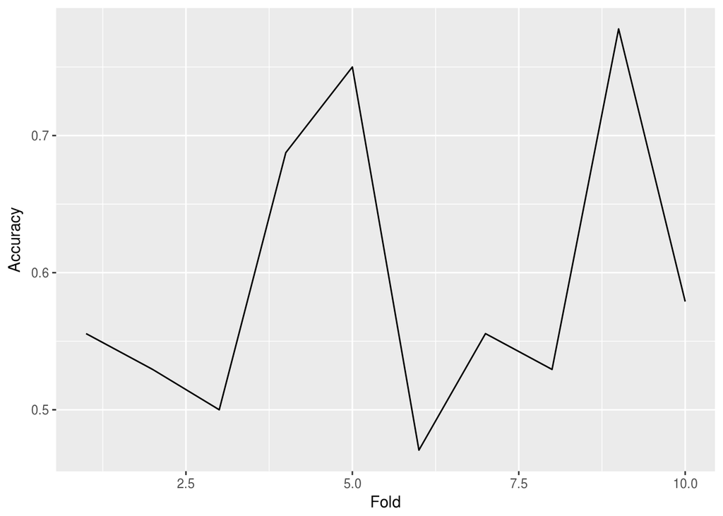

```r
ggplot() + geom_line(aes(y = model$resample$Accuracy, x = 1:10)) + xlab("Fold") + ylab("Accuracy")
```

Посмотрим предсказание на первоначальной тестовой выборке.

```r
Glass.predictionsTest.cv <- predict(model, GlassTest)
cmTest.cv = confusionMatrix(Glass.predictionsTest.cv, GlassTest$Type)
cmTest.cv
```

```
## Confusion Matrix and Statistics
##
##           Reference
## Prediction  1  2  3  5  6  7
##          1 11  5  2  0  0  1
##          2  3  8  0  0  0  0
##          3  0  1  1  0  0  0
##          5  0  0  0  1  0  1
##          6  0  1  0  1  0  0
##          7  0  0  0  0  1  3
##
## Overall Statistics
##
##                Accuracy : 0.6
##                  95% CI : (0.4333, 0.7514)
##     No Information Rate : 0.375
##     P-Value [Acc > NIR] : 0.003206
##
##                   Kappa : 0.4371
##  Mcnemar's Test P-Value : NA
##
## Statistics by Class:
##
##                      Class: 1 Class: 2 Class: 3 Class: 5 Class: 6 Class: 7
## Sensitivity            0.7857   0.5333   0.3333   0.5000   0.0000   0.6000
## Specificity            0.6923   0.8800   0.9730   0.9737   0.9487   0.9714
## Pos Pred Value         0.5789   0.7273   0.5000   0.5000   0.0000   0.7500
## Neg Pred Value         0.8571   0.7586   0.9474   0.9737   0.9737   0.9444
## Prevalence             0.3500   0.3750   0.0750   0.0500   0.0250   0.1250
## Detection Rate         0.2750   0.2000   0.0250   0.0250   0.0000   0.0750
## Detection Prevalence   0.4750   0.2750   0.0500   0.0500   0.0500   0.1000
## Balanced Accuracy      0.7390   0.7067   0.6532   0.7368   0.4744   0.7857
```

- Что вы можете сказать о результатах?

#### Leave One Out Cross Validation

Частный случай k-fold валидации, где k = числу наблюдений (NB! работает долго)

```r
train_control <- trainControl(method="LOOCV")
model2 <- train(Type~., data=GlassTrain, trControl=train_control, method="ctree")
print(model2)
Glass.predictionsTest.cv2 <- predict(model, GlassTest)
cmTest.cv2 = confusionMatrix(Glass.predictionsTest.cv2, GlassTest$Type)
cmTest.cv2
```

#### Repeated k-fold Cross Validation

k-fold валидации повторяется несколько раз, результаты усредняются

```r
train_control <- trainControl(method="repeatedcv", number=10, repeats=5)
model3 <- train(Type~., data=GlassTrain, trControl=train_control, method="ctree")
print(model3)
```

```
## Conditional Inference Tree
##
## 174 samples
##   9 predictors
##   6 classes: '1', '2', '3', '5', '6', '7'
##
## No pre-processing
## Resampling: Cross-Validated (10 fold, repeated 5 times)
## Summary of sample sizes: 156, 155, 157, 156, 158, 156, ...
## Resampling results across tuning parameters:
##
##   mincriterion  Accuracy   Kappa
##   0.01          0.5789914  0.4237878
##   0.50          0.5732675  0.4112333
##   0.99          0.5830068  0.4198834
##
## Accuracy was used to select the optimal model using  the largest value.
## The final value used for the model was mincriterion = 0.99.
```

```r
Glass.predictionsTest.cv3 <- predict(model, GlassTest)
cmTest.cv3 = confusionMatrix(Glass.predictionsTest.cv3, GlassTest$Type)
cmTest.cv3
```

```
## Confusion Matrix and Statistics
##
##           Reference
## Prediction  1  2  3  5  6  7
##          1 11  5  2  0  0  1
##          2  3  8  0  0  0  0
##          3  0  1  1  0  0  0
##          5  0  0  0  1  0  1
##          6  0  1  0  1  0  0
##          7  0  0  0  0  1  3
##
## Overall Statistics
##
##                Accuracy : 0.6
##                  95% CI : (0.4333, 0.7514)
##     No Information Rate : 0.375
##     P-Value [Acc > NIR] : 0.003206
##
##                   Kappa : 0.4371
##  Mcnemar's Test P-Value : NA
##
## Statistics by Class:
##
##                      Class: 1 Class: 2 Class: 3 Class: 5 Class: 6 Class: 7
## Sensitivity            0.7857   0.5333   0.3333   0.5000   0.0000   0.6000
## Specificity            0.6923   0.8800   0.9730   0.9737   0.9487   0.9714
## Pos Pred Value         0.5789   0.7273   0.5000   0.5000   0.0000   0.7500
## Neg Pred Value         0.8571   0.7586   0.9474   0.9737   0.9737   0.9444
## Prevalence             0.3500   0.3750   0.0750   0.0500   0.0250   0.1250
## Detection Rate         0.2750   0.2000   0.0250   0.0250   0.0000   0.0750
## Detection Prevalence   0.4750   0.2750   0.0500   0.0500   0.0500   0.1000
## Balanced Accuracy      0.7390   0.7067   0.6532   0.7368   0.4744   0.7857
```

### Данные: регрессия

Взаимосвязь рекламы и уровня продаж

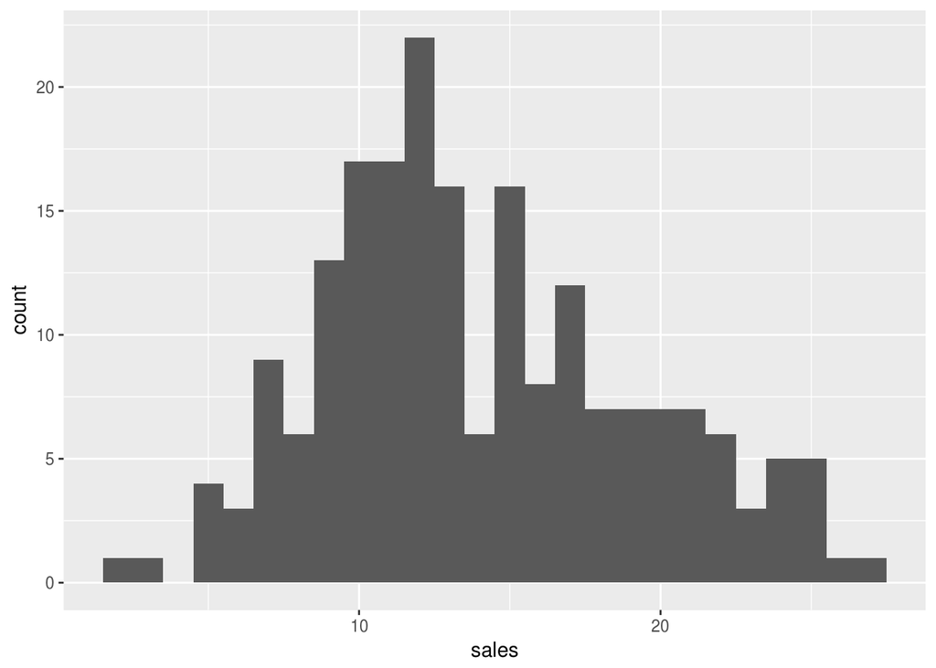

```r
Advertising = read.csv("~/shared/minor3_2017/3-SecondYear-ML/practice-3-cv/Advertising.csv")
Advertising = Advertising[,-1]
ggplot(data = Advertising) + geom_histogram(aes(x = sales), binwidth = 1)
```

Разделим на тестовую и обучающую

```r
set.seed(3)
trainIndex <- createDataPartition(Advertising$sales, p = .8,
                                  list = FALSE,
                                  times = 1)
head(trainIndex)
```

```
##      Resample1
## [1,]         1
## [2,]         3
## [3,]         4
## [4,]         5
## [5,]         7
## [6,]         8
```

```r
AdvTrain <- Advertising[ trainIndex,]
AdvTest  <- Advertising[-trainIndex,]
```

Строим модель

```r
modelLM<-lm(sales ~., data=AdvTrain)
summary(modelLM)
```

```
##
## Call:
## lm(formula = sales ~ ., data = AdvTrain)
##
## Residuals:
##     Min      1Q  Median      3Q     Max
## -8.8553 -0.9167  0.2552  1.1940  2.7737
##
## Coefficients:
##               Estimate Std. Error t value Pr(>|t|)
## (Intercept)  3.0114859  0.3538125   8.512 1.25e-14 ***
## TV           0.0454454  0.0015879  28.620  < 2e-16 ***
## radio        0.1872774  0.0093910  19.942  < 2e-16 ***
## newspaper   -0.0004752  0.0066167  -0.072    0.943
## ---
## Signif. codes:  0 '***' 0.001 '**' 0.01 '*' 0.05 '.' 0.1 ' ' 1
##
## Residual standard error: 1.694 on 158 degrees of freedom
## Multiple R-squared:  0.8946, Adjusted R-squared:  0.8925
## F-statistic: 446.8 on 3 and 158 DF,  p-value: < 2.2e-16
```

**Ваша очередь:** Посчитайте ошибку предсказания на обучающей и тестовой выборке

Посчитаем немного другой показатель ошибки – RMSE

```r
Adv.predictionsTest <- predict(modelLM, AdvTest)
RMSE = sqrt(mean((Adv.predictionsTest - AdvTest$sales)^2))
RMSE
```

```
## [1] 1.652711
```

Построим модель методом кросс-валидации

```r
train_control <- trainControl(method="cv", number=10)
modelLM.cv <- train(sales~., data=AdvTrain,
                    trControl=trainControl(method="cv", number=10),
                    method="lm")
print(modelLM.cv)
```

```
## Linear Regression
##
## 162 samples
##   3 predictors
##
## No pre-processing
## Resampling: Cross-Validated (10 fold)
## Summary of sample sizes: 146, 146, 146, 145, 146, 146, ...
## Resampling results:
##
##   RMSE      Rsquared
##   1.656955  0.9040308
##
##
```

```r
modelLM.cv$resample
```

```
##        RMSE  Rsquared Resample
## 1  1.656991 0.9110865   Fold01
## 2  1.500099 0.9023514   Fold02
## 3  1.210458 0.9354834   Fold03
## 4  1.642483 0.8949223   Fold04
## 5  1.936945 0.8732265   Fold05
## 6  1.745689 0.9223147   Fold06
## 7  1.625646 0.9080983   Fold07
## 8  1.176793 0.9604575   Fold08
## 9  1.185722 0.9372422   Fold09
## 10 2.888723 0.7951248   Fold10
```

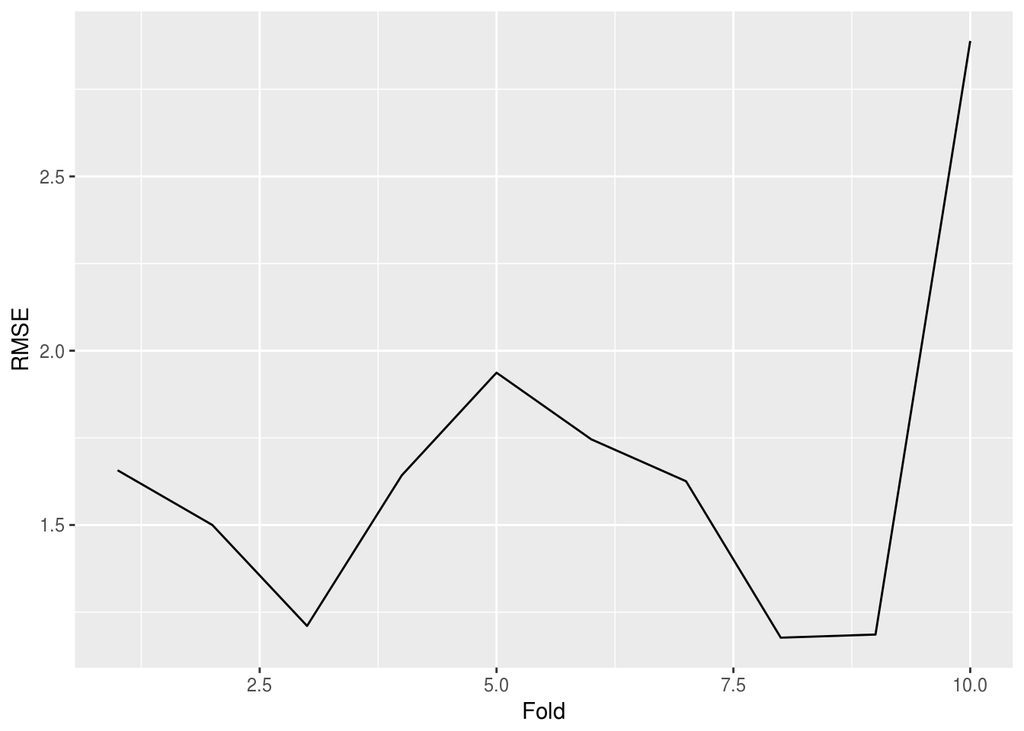

```r
ggplot() + geom_line(aes(y = modelLM.cv$resample$RMSE, x = 1:10)) + xlab("Fold") + ylab("RMSE")
```

```r
sd(modelLM.cv$resample$RMSE)
```

```
## [1] 0.5034647
```

Посмотрим предсказание на первоначальной тестовой выборке.

```r
Adv.predictionsTest.cv <- predict(modelLM.cv, AdvTest)
RMSE.cv = sqrt(mean((Adv.predictionsTest.cv - AdvTest$sales)^2))
RMSE.cv
```

```
## [1] 1.652711
```

- Что вы можете сказать о результатах?
- Попробуйте другие параметры кросс-валидации. Что изменилось?

**Ваша очередь:** Постройте регрессионную модель с помощью дерева решений, используя метод кросс-валидации. Сравните с линейной регрессией

**Ваша очередь:**

Постройте модели для следующих наборов данных (не забудьте посмотреть справку и определить тип задачи (регрессия или классификация)

```r
library(ISLR)
```

1. `Wage`, предсказываемая переменная `wage`

```r
?ISLR::Wage
library(dplyr)
Wage = ISLR::Wage
table(Wage$region)
```

2. `Caravan`, предсказываемая переменная `Purchase`

```r
?ISLR::Caravan
caravan = ISLR::Caravan

## возможный способ сокращения ответов "Нет"
library(dplyr)
caravanNo = filter(caravan, Purchase == "No")
caravanNo = sample_n(caravanNo, size = 400)
caravan = caravan %>% filter(Purchase == "Yes") %>% rbind(caravanNo)
```